# Loan Prediction (Binary Classification)

```python
# Importing required Libraries
import pandas as pd
import matplotlib.pyplot as plt
import seaborn as sb
```

```python
A = pd.read_csv("C:/Work/DATA_SCI-ANA/Datasets/Loan_Prediction/training_set.csv")
```

```python
from warnings import filterwarnings
filterwarnings("ignore")
```

#### Dataset at a glance

```python
A.shape
```

```
(614, 13)
```

```python
A.head()
```

|  | Loan_ID | Gender | Married | Dependents | Education | Self_Employed | ApplicantIncome | CoapplicantIncome | LoanAmount | Loan_Amount_Term | Credit_History | Property_Area | Loan_Status |
| --- | --- | --- | --- | --- | --- | --- | --- | --- | --- | --- | --- | --- | --- |
| 0 | LP001002 | Male | No | 0 | Graduate | No | 5849.0 | 0.0 | NaN | 360.0 | 1.0 | Urban | Y |
| 1 | LP001003 | Male | Yes | 1 | Graduate | No | NaN | 1508.0 | 128.0 | 360.0 | 1.0 | Rural | N |
| 2 | LP001005 | Male | Yes | 0 | Graduate | Yes | 3000.0 | 0.0 | 66.0 | 360.0 | 1.0 | Urban | Y |
| 3 | LP001006 | Male | Yes | 0 | Not Graduate | No | 2583.0 | 2358.0 | 120.0 | 360.0 | 1.0 | Urban | Y |
| 4 | LP001008 | Male | No | 0 | Graduate | No | 6000.0 | 0.0 | 141.0 | 360.0 | 1.0 | Urban | Y |

```python
A.describe()
```

|  | ApplicantIncome | CoapplicantIncome | LoanAmount | Loan_Amount_Term | Credit_History |
| --- | --- | --- | --- | --- | --- |
| count | 612.000000 | 613.000000 | 592.000000 | 600.00000 | 564.000000 |
| mean | 5405.540850 | 1620.888940 | 146.412162 | 342.00000 | 0.842199 |
| std | 6118.914057 | 2928.624748 | 85.587325 | 65.12041 | 0.364878 |
| min | 150.000000 | 0.000000 | 9.000000 | 12.00000 | 0.000000 |
| 25% | 2875.750000 | 0.000000 | 100.000000 | 360.00000 | 1.000000 |
| 50% | 3806.000000 | 1167.000000 | 128.000000 | 360.00000 | 1.000000 |
| 75% | 5803.750000 | 2302.000000 | 168.000000 | 360.00000 | 1.000000 |
| max | 81000.000000 | 41667.000000 | 700.000000 | 480.00000 | 1.000000 |

```python
A.isna().sum()
```

```
Loan_ID               0
Gender               15
Married               3
Dependents           15
Education             1
Self_Employed        32
ApplicantIncome       2
CoapplicantIncome     1
LoanAmount           22
Loan_Amount_Term     14
Credit_History       50
Property_Area         0
Loan_Status           0
dtype: int64
```

```python
A.Loan_Status.value_counts()
```

```
Y    422
N    192
Name: Loan_Status, dtype: int64
```

#### Exploratory Data Analysis

#### 1.Treating missing values

```python
for i in A.columns:
    if (A[i].dtypes == 'object'):
        x = A[i].mode()[0]
        A[i] = A[i].fillna(x)
    else:
        x = A[i].mean()
        A[i] = A[i].fillna(x)
```

```python
# Checking for missing values

A.isna().sum()
```

```
Loan_ID              0
Gender               0
Married              0
Dependents           0
Education            0
Self_Employed        0
ApplicantIncome      0
CoapplicantIncome    0
LoanAmount           0
Loan_Amount_Term     0
Credit_History       0
Property_Area        0
Loan_Status          0
dtype: int64
```

#### 2. Diffrentiating Data on basis of data types

```python
cat = []
con = []


for i in A.columns:
    if (A[i].dtypes == 'object'):
        cat.append(i)
    else:
        con.append(i)
```

```python
#categorical columns

cat
```

```
['Loan_ID',
 'Gender',
 'Married',
 'Dependents',
 'Education',
 'Self_Employed',
 'Property_Area',
 'Loan_Status']
```

```python
#continuous columns

con
```

```
['ApplicantIncome',
 'CoapplicantIncome',
 'LoanAmount',
 'Loan_Amount_Term',
 'Credit_History']
```

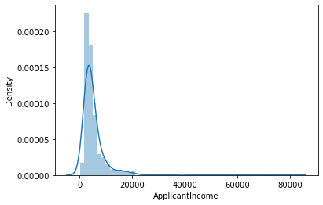

```python
sb.distplot(A['ApplicantIncome'])
```

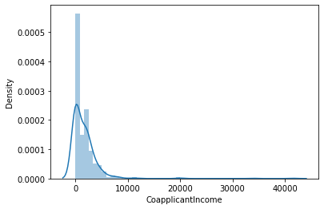

```python
sb.distplot(A['CoapplicantIncome'])
```

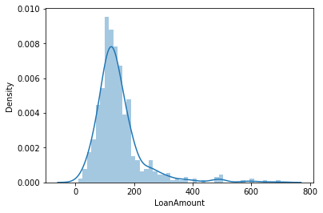

```python
sb.distplot(A['LoanAmount'])
```

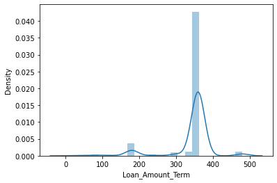

```python
sb.distplot(A['Loan_Amount_Term'])
```

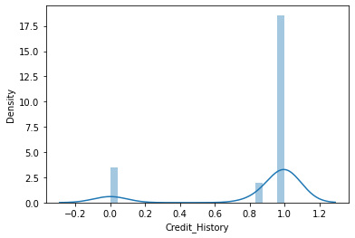

```python
sb.distplot(A['Credit_History'])
```

Graphical representation above of continuous variables confirms outliers, there are 2 ways to solve:

1. Standardisation
2. Yeo-Jhonson Method

#### 3) Treating Outliers

method{‘yeo-johnson’, ‘box-cox’}, default=’yeo-johnson’

```python
from sklearn.preprocessing import PowerTransformer
pt = PowerTransformer()
conti = pt.fit_transform(A[con])
```

```python
conti = pd.DataFrame(conti,columns = con)
```

```python
conti
```

|  | ApplicantIncome | CoapplicantIncome | LoanAmount | Loan_Amount_Term | Credit_History |
| --- | --- | --- | --- | --- | --- |
| 0 | 0.543507 | -1.102830 | 0.235387 | 0.185905 | 0.514063 |
| 1 | 0.423838 | 0.750689 | -0.037659 | 0.185905 | 0.514063 |
| 2 | -0.500567 | -1.102830 | -1.346305 | 0.185905 | 0.514063 |
| 3 | -0.744401 | 0.891798 | -0.167886 | 0.185905 | 0.514063 |
| 4 | 0.581990 | -1.102830 | 0.158610 | 0.185905 | 0.514063 |
| ... | ... | ... | ... | ... | ... |
| 609 | -0.555480 | -1.102830 | -1.205100 | 0.185905 | 0.514063 |
| 610 | -0.001034 | -1.102830 | -2.293317 | -2.308570 | 0.514063 |
| 611 | 1.022648 | 0.208701 | 1.372409 | 0.185905 | 0.514063 |
| 612 | 0.930911 | -1.102830 | 0.738924 | 0.185905 | 0.514063 |
| 613 | 0.170198 | -1.102830 | 0.039936 | 0.185905 | -2.247196 |

614 rows × 5 columns

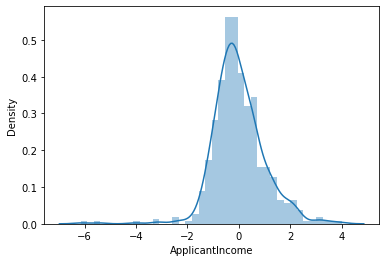

```python
sb.distplot(conti['ApplicantIncome'])
```

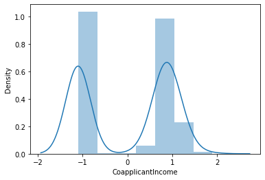

```python
sb.distplot(conti['CoapplicantIncome'])
```

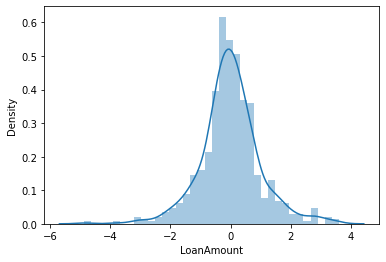

```python
sb.distplot(conti['LoanAmount'])
```

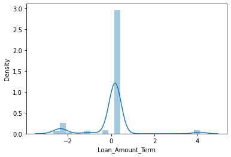

```python
sb.distplot(conti['Loan_Amount_Term'])
```

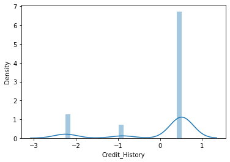

```python
sb.distplot(conti['Credit_History'])
```

```python
# Most of the columns are cured for outliers
```

#### 4) One Hot Encoding Categorical Variables

```python
cate = A[cat]
```

```python
cate = cate.drop(columns = ['Loan_ID']) #dropped discrete column
```

```python
cate = pd.get_dummies(cate)
```

```python
cate
```

|  | Gender_Female | Gender_Male | Married_No | Married_Yes | Dependents_0 | Dependents_1 | Dependents_2 | Dependents_3+ | Education_Graduate | Education_Not Graduate | Self_Employed_No | Self_Employed_Yes | Property_Area_Rural | Property_Area_Semiurban | Property_Area_Urban | Loan_Status_N | Loan_Status_Y |
| --- | --- | --- | --- | --- | --- | --- | --- | --- | --- | --- | --- | --- | --- | --- | --- | --- | --- |
| 0 | 0 | 1 | 1 | 0 | 1 | 0 | 0 | 0 | 1 | 0 | 1 | 0 | 0 | 0 | 1 | 0 | 1 |
| 1 | 0 | 1 | 0 | 1 | 0 | 1 | 0 | 0 | 1 | 0 | 1 | 0 | 1 | 0 | 0 | 1 | 0 |
| 2 | 0 | 1 | 0 | 1 | 1 | 0 | 0 | 0 | 1 | 0 | 0 | 1 | 0 | 0 | 1 | 0 | 1 |
| 3 | 0 | 1 | 0 | 1 | 1 | 0 | 0 | 0 | 0 | 1 | 1 | 0 | 0 | 0 | 1 | 0 | 1 |
| 4 | 0 | 1 | 1 | 0 | 1 | 0 | 0 | 0 | 1 | 0 | 1 | 0 | 0 | 0 | 1 | 0 | 1 |
| ... | ... | ... | ... | ... | ... | ... | ... | ... | ... | ... | ... | ... | ... | ... | ... | ... | ... |
| 609 | 1 | 0 | 1 | 0 | 1 | 0 | 0 | 0 | 1 | 0 | 1 | 0 | 1 | 0 | 0 | 0 | 1 |
| 610 | 0 | 1 | 0 | 1 | 0 | 0 | 0 | 1 | 1 | 0 | 1 | 0 | 1 | 0 | 0 | 0 | 1 |
| 611 | 0 | 1 | 0 | 1 | 0 | 1 | 0 | 0 | 1 | 0 | 1 | 0 | 0 | 0 | 1 | 0 | 1 |
| 612 | 0 | 1 | 0 | 1 | 0 | 0 | 1 | 0 | 1 | 0 | 1 | 0 | 0 | 0 | 1 | 0 | 1 |
| 613 | 1 | 0 | 1 | 0 | 1 | 0 | 0 | 0 | 1 | 0 | 0 | 1 | 0 | 1 | 0 | 1 | 0 |

614 rows × 17 columns

```python
df = conti.join(cate)
```

```python
df
```

|  | ApplicantIncome | CoapplicantIncome | LoanAmount | Loan_Amount_Term | Credit_History | Gender_Female | Gender_Male | Married_No | Married_Yes | Dependents_0 | ... | Dependents_3+ | Education_Graduate | Education_Not Graduate | Self_Employed_No | Self_Employed_Yes | Property_Area_Rural | Property_Area_Semiurban | Property_Area_Urban | Loan_Status_N | Loan_Status_Y |
| --- | --- | --- | --- | --- | --- | --- | --- | --- | --- | --- | --- | --- | --- | --- | --- | --- | --- | --- | --- | --- | --- |
| 0 | 0.543507 | -1.102830 | 0.235387 | 0.185905 | 0.514063 | 0 | 1 | 1 | 0 | 1 | ... | 0 | 1 | 0 | 1 | 0 | 0 | 0 | 1 | 0 | 1 |
| 1 | 0.423838 | 0.750689 | -0.037659 | 0.185905 | 0.514063 | 0 | 1 | 0 | 1 | 0 | ... | 0 | 1 | 0 | 1 | 0 | 1 | 0 | 0 | 1 | 0 |
| 2 | -0.500567 | -1.102830 | -1.346305 | 0.185905 | 0.514063 | 0 | 1 | 0 | 1 | 1 | ... | 0 | 1 | 0 | 0 | 1 | 0 | 0 | 1 | 0 | 1 |
| 3 | -0.744401 | 0.891798 | -0.167886 | 0.185905 | 0.514063 | 0 | 1 | 0 | 1 | 1 | ... | 0 | 0 | 1 | 1 | 0 | 0 | 0 | 1 | 0 | 1 |
| 4 | 0.581990 | -1.102830 | 0.158610 | 0.185905 | 0.514063 | 0 | 1 | 1 | 0 | 1 | ... | 0 | 1 | 0 | 1 | 0 | 0 | 0 | 1 | 0 | 1 |
| ... | ... | ... | ... | ... | ... | ... | ... | ... | ... | ... | ... | ... | ... | ... | ... | ... | ... | ... | ... | ... | ... |
| 609 | -0.555480 | -1.102830 | -1.205100 | 0.185905 | 0.514063 | 1 | 0 | 1 | 0 | 1 | ... | 0 | 1 | 0 | 1 | 0 | 1 | 0 | 0 | 0 | 1 |
| 610 | -0.001034 | -1.102830 | -2.293317 | -2.308570 | 0.514063 | 0 | 1 | 0 | 1 | 0 | ... | 1 | 1 | 0 | 1 | 0 | 1 | 0 | 0 | 0 | 1 |
| 611 | 1.022648 | 0.208701 | 1.372409 | 0.185905 | 0.514063 | 0 | 1 | 0 | 1 | 0 | ... | 0 | 1 | 0 | 1 | 0 | 0 | 0 | 1 | 0 | 1 |
| 612 | 0.930911 | -1.102830 | 0.738924 | 0.185905 | 0.514063 | 0 | 1 | 0 | 1 | 0 | ... | 0 | 1 | 0 | 1 | 0 | 0 | 0 | 1 | 0 | 1 |
| 613 | 0.170198 | -1.102830 | 0.039936 | 0.185905 | -2.247196 | 1 | 0 | 1 | 0 | 1 | ... | 0 | 1 | 0 | 0 | 1 | 0 | 1 | 0 | 1 | 0 |

614 rows × 22 columns

#### 5) Checking the relation {X ~ Y}

- Y = Loan_Status is the categorical variable
- If Y is categorical and X is continuous we use boxplot or ANOVA
- If Y is categorical and X is categorical we use countplot with hue, cross tabulation, Chi_Square Test

a. First we will go with continuous

```python
con
```

```
['ApplicantIncome',
 'CoapplicantIncome',
 'LoanAmount',
 'Loan_Amount_Term',
 'Credit_History']
```

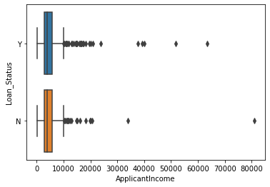

```python
sb.boxplot(A['ApplicantIncome'],A['Loan_Status'])
```

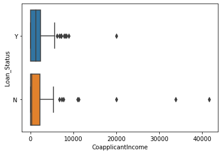

```python
sb.boxplot(A['CoapplicantIncome'],A['Loan_Status'])
```

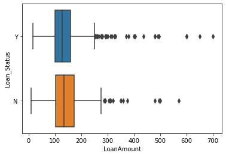

```python
sb.boxplot(A['LoanAmount'],A['Loan_Status'])
```

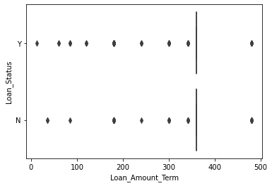

```python
sb.boxplot(A['Loan_Amount_Term'],A['Loan_Status'])
```

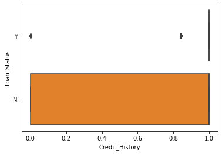

```python
sb.boxplot(A['Credit_History'],A['Loan_Status'])
```

Checking the relation between Y and X(continuous) using pvalues

```python
from scipy.stats import chi2_contingency
for i in conti:
    Q = pd.crosstab(A.Loan_Status,conti[i])
    a,b,c,d = chi2_contingency(Q)
    print(i,"~~",b)
```

```
ApplicantIncome ~~ 0.445970304541267
CoapplicantIncome ~~ 0.5702980314497069
LoanAmount ~~ 0.4372624752205558
Loan_Amount_Term ~~ 0.1379445122345725
Credit_History ~~ 7.926164541543543e-40
```

According to pvalue we see only credit history has best relation with Loan_Status

```python
for i in A[cat]:
    Q = pd.crosstab(A.Loan_Status,A[i])
    a,b,c,d = chi2_contingency(Q)
    print(i,'~~',a)
```

```
Loan_ID ~~ 614.0000000000002
Gender ~~ 0.11087854691241235
Married ~~ 4.73187557933362
Dependents ~~ 3.1513990012324227
Education ~~ 4.091490413303621
Self_Employed ~~ 0.0
Property_Area ~~ 12.297623130485677
Loan_Status ~~ 609.355921937585
```

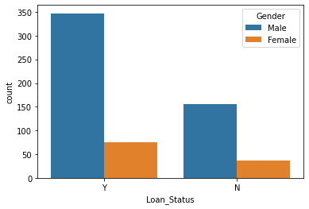

```python
sb.countplot(A.Loan_Status,hue = A.Gender)
```

```python
A['Gender'].value_counts()
```

```
Male      502
Female    112
Name: Gender, dtype: int64
```

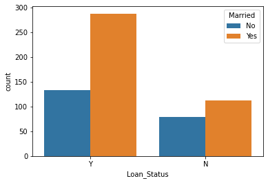

```python
sb.countplot(A.Loan_Status,hue = A.Married)
```

```python
A['Married'].value_counts()
```

```
Yes    401
No     213
Name: Married, dtype: int64
```

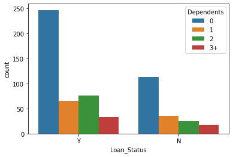

```python
sb.countplot(A.Loan_Status,hue = A.Dependents)
```

```python
A['Dependents'].value_counts()
```

```
0     360
1     102
2     101
3+     51
Name: Dependents, dtype: int64
```

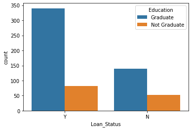

```python
sb.countplot(A.Loan_Status,hue = A.Education)
```

```python
A['Education'].value_counts()
```

```
Graduate        480
Not Graduate    134
Name: Education, dtype: int64
```

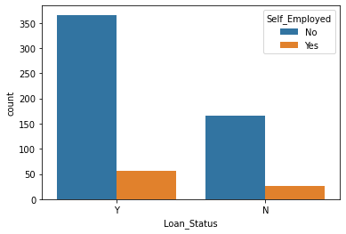

```python
sb.countplot(A.Loan_Status,hue = A.Self_Employed)
```

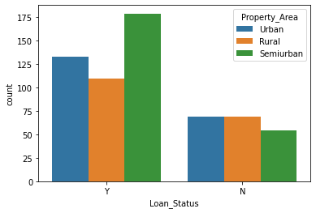

```python
sb.countplot(A.Loan_Status,hue = A.Property_Area)
```

### Observations :

#### 1) Training set has 614 observations and 13 characteristics

#### 2) Highest number of missing value is seen in column named credit history which is also a important column to decide weather loan should be given on not

#### 3) There is difference between mean and 50th percentile also there is large difference between 75th percentile and max values indicating we have outliers in dataset

#### 4) Number of "Yes" is far greater than number of "No" in target variable

#### 5) Majority of columns are biased which might create varience

#### 6) Gender and Self_Employed columns dose not have good relation with Loan_Status

```python
df #dataset ready to use
```

|  | ApplicantIncome | CoapplicantIncome | LoanAmount | Loan_Amount_Term | Credit_History | Gender_Female | Gender_Male | Married_No | Married_Yes | Dependents_0 | ... | Dependents_3+ | Education_Graduate | Education_Not Graduate | Self_Employed_No | Self_Employed_Yes | Property_Area_Rural | Property_Area_Semiurban | Property_Area_Urban | Loan_Status_N | Loan_Status_Y |
| --- | --- | --- | --- | --- | --- | --- | --- | --- | --- | --- | --- | --- | --- | --- | --- | --- | --- | --- | --- | --- | --- |
| 0 | 0.543507 | -1.102830 | 0.235387 | 0.185905 | 0.514063 | 0 | 1 | 1 | 0 | 1 | ... | 0 | 1 | 0 | 1 | 0 | 0 | 0 | 1 | 0 | 1 |
| 1 | 0.423838 | 0.750689 | -0.037659 | 0.185905 | 0.514063 | 0 | 1 | 0 | 1 | 0 | ... | 0 | 1 | 0 | 1 | 0 | 1 | 0 | 0 | 1 | 0 |
| 2 | -0.500567 | -1.102830 | -1.346305 | 0.185905 | 0.514063 | 0 | 1 | 0 | 1 | 1 | ... | 0 | 1 | 0 | 0 | 1 | 0 | 0 | 1 | 0 | 1 |
| 3 | -0.744401 | 0.891798 | -0.167886 | 0.185905 | 0.514063 | 0 | 1 | 0 | 1 | 1 | ... | 0 | 0 | 1 | 1 | 0 | 0 | 0 | 1 | 0 | 1 |
| 4 | 0.581990 | -1.102830 | 0.158610 | 0.185905 | 0.514063 | 0 | 1 | 1 | 0 | 1 | ... | 0 | 1 | 0 | 1 | 0 | 0 | 0 | 1 | 0 | 1 |
| ... | ... | ... | ... | ... | ... | ... | ... | ... | ... | ... | ... | ... | ... | ... | ... | ... | ... | ... | ... | ... | ... |
| 609 | -0.555480 | -1.102830 | -1.205100 | 0.185905 | 0.514063 | 1 | 0 | 1 | 0 | 1 | ... | 0 | 1 | 0 | 1 | 0 | 1 | 0 | 0 | 0 | 1 |
| 610 | -0.001034 | -1.102830 | -2.293317 | -2.308570 | 0.514063 | 0 | 1 | 0 | 1 | 0 | ... | 1 | 1 | 0 | 1 | 0 | 1 | 0 | 0 | 0 | 1 |
| 611 | 1.022648 | 0.208701 | 1.372409 | 0.185905 | 0.514063 | 0 | 1 | 0 | 1 | 0 | ... | 0 | 1 | 0 | 1 | 0 | 0 | 0 | 1 | 0 | 1 |
| 612 | 0.930911 | -1.102830 | 0.738924 | 0.185905 | 0.514063 | 0 | 1 | 0 | 1 | 0 | ... | 0 | 1 | 0 | 1 | 0 | 0 | 0 | 1 | 0 | 1 |
| 613 | 0.170198 | -1.102830 | 0.039936 | 0.185905 | -2.247196 | 1 | 0 | 1 | 0 | 1 | ... | 0 | 1 | 0 | 0 | 1 | 0 | 1 | 0 | 1 | 0 |

614 rows × 22 columns

#### Making dataset ready for models

```python
X = df.drop(columns = ['Loan_Status_N','Loan_Status_Y'])
```

```python
Y = A[['Loan_Status']]
```

```python
# splitting the dataset for training and testing

from sklearn.model_selection import train_test_split
xtrain,xtest,ytrain,ytest = train_test_split(X,Y,random_state= 21, test_size= 0.4)
```

#### Model -1 ] Decision Tree Classifier

```python
tr = []
ts = []
for i in range(2,20,1):
    from sklearn.tree import DecisionTreeClassifier
    dtc = DecisionTreeClassifier(criterion="entropy",random_state=21,max_depth=i,min_samples_leaf=i,min_samples_split=i)

    model = dtc.fit(xtrain,ytrain)
    pred_tr = model.predict(xtrain)
    pred_ts = model.predict(xtest)

    #training error
    from sklearn.metrics import accuracy_score,confusion_matrix
    tr_acc = accuracy_score(ytrain,pred_tr)
    tr_con = confusion_matrix(ytrain,pred_tr)

    tr.append(tr_acc)

    #testing error
    ts_acc = accuracy_score(ytest,pred_ts)
    ts_con = confusion_matrix(ytest,pred_ts)

    ts.append(ts_acc)
```

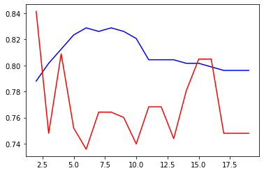

```python
import matplotlib.pyplot as plt
plt.plot(range(2,20,1),tr,c="blue")
plt.plot(range(2,20,1),ts,c="red")
```

#### Model-2] Random Forest Classifier (Bagging Approach)

```python
from sklearn.model_selection import GridSearchCV
from sklearn.ensemble import RandomForestClassifier
```

```python
param_grid = {
    'n_estimators': [200, 500],
    'max_features': ['auto', 'sqrt', 'log2'],
    'max_depth' : [4,5,6,7,8],
    'criterion' :['gini', 'entropy']
}
```

```python
rfc = RandomForestClassifier()
CV_rfc = GridSearchCV(estimator=rfc, param_grid=param_grid, cv= 5)
CV_rfc.fit(xtrain, ytrain)
```

```
GridSearchCV(cv=5, estimator=RandomForestClassifier(),
             param_grid={'criterion': ['gini', 'entropy'],
                         'max_depth': [4, 5, 6, 7, 8],
                         'max_features': ['auto', 'sqrt', 'log2'],
                         'n_estimators': [200, 500]})
```

```python
CV_rfc.best_params_
```

```
{'criterion': 'entropy',
 'max_depth': 4,
 'max_features': 'auto',
 'n_estimators': 200}
```

```python
rfc = RandomForestClassifier(random_state= 21, criterion= 'entropy',max_depth= 4, max_features= 'log2',n_estimators = 200)
```

```python
model = rfc.fit(xtrain,ytrain)
pred_tr = model.predict(xtrain)
pred_ts = model.predict(xtest)
#training error
tr_acc = accuracy_score(ytrain,pred_tr)

tr.append(tr_acc)

#testing error
ts_acc = accuracy_score(ytest,pred_ts)

ts.append(ts_acc)
```

```python
tr_acc
```

```
0.7961956521739131
```

```python
ts_acc
```

```
0.8414634146341463
```